# R Notebook

> First the data is imported from a CSV file

```r
library(ggplot2)
library(dplyr)
library(tidyr)
options(device = "quartz")

codes <- read.csv(file="offense_codes.csv", header=TRUE, sep=",")
crimes <- read.csv(file="crime.csv", header=TRUE, sep=",")
```

> Take a sneak peak at the data to understand the columns present in the csv

```r
print(ncol(crimes))
```

```
## [1] 17
```

```r
head(crimes,2)
```

|  | INCIDENT_NUMBER | OFFENSE_CODE | OFFENSE_CODE_GROUP | OFFENSE_DESCRIPTION | DISTRICT | REPORTING_AREA | SHOOTING | OCCURRED_ON_DATE | YEAR | MONTH | DAY_OF_WEEK | HOUR | UCR_PART | STREET | Lat | Long | Location |
| --- | --- | --- | --- | --- | --- | --- | --- | --- | --- | --- | --- | --- | --- | --- | --- | --- | --- |
| 1 | I182070945 | 619 | Larceny | LARCENY ALL OTHERS | D14 | 808 |  | 2018-09-02 13:00:00 | 2018 | 9 | Sunday | 13 | Part One | LINCOLN ST | 42.35779 | -71.13937 | (42.35779134, -71.13937053) |
| 2 | I182070943 | 1402 | Vandalism | VANDALISM | C11 | 347 |  | 2018-08-21 00:00:00 | 2018 | 8 | Tuesday | 0 | Part Two | HECLA ST | 42.30682 | -71.06030 | (42.30682138, -71.06030035) |

```r
str(crimes)
```

```
## 'data.frame':    319073 obs. of  17 variables:
##  $ INCIDENT_NUMBER    : Factor w/ 282517 levels "142052550","I010370257-00",..: 282517 282516 282515 282514 282513 282512 282511 282510 282509 282508 ...
##  $ OFFENSE_CODE       : int  619 1402 3410 3114 3114 3820 724 3301 301 3301 ...
##  $ OFFENSE_CODE_GROUP : Factor w/ 67 levels "Aggravated Assault",..: 35 64 63 33 33 44 5 65 59 65 ...
##  $ OFFENSE_DESCRIPTION: Factor w/ 244 levels "A&B HANDS, FEET, ETC.  - MED. ATTENTION REQ.",..: 130 231 223 124 124 165 22 232 207 232 ...
##  $ DISTRICT           : Factor w/ 13 levels "","A1","A15",..: 9 7 10 10 6 7 5 5 8 7 ...
##  $ REPORTING_AREA     : int  808 347 151 272 421 398 330 584 177 364 ...
##  $ SHOOTING           : Factor w/ 2 levels "","Y": 1 1 1 1 1 1 1 1 1 1 ...
##  $ OCCURRED_ON_DATE   : Factor w/ 233229 levels "2015-06-15 00:00:00",..: 232988 230467 233216 233228 233226 233227 233229 233224 233225 233222 ...
##  $ YEAR               : int  2018 2018 2018 2018 2018 2018 2018 2018 2018 2018 ...
##  $ MONTH              : int  9 8 9 9 9 9 9 9 9 9 ...
##  $ DAY_OF_WEEK        : Factor w/ 7 levels "Friday","Monday",..: 4 6 2 2 2 2 2 2 2 2 ...
##  $ HOUR               : int  13 0 19 21 21 21 21 20 20 20 ...
##  $ UCR_PART           : Factor w/ 5 levels "","Other","Part One",..: 3 5 4 4 4 4 3 4 3 4 ...
##  $ STREET             : Factor w/ 4658 levels ""," ALBANY ST ",..: 2537 2075 786 3067 1242 4075 3100 2461 2742 2505 ...
##  $ Lat                : num  42.4 42.3 42.3 42.3 42.3 ...
##  $ Long               : num  -71.1 -71.1 -71.1 -71.1 -71.1 ...
##  $ Location           : Factor w/ 18194 levels "(-1.00000000, -1.00000000)",..: 15616 6832 13472 11292 2034 4673 6752 10012 10748 5513 ...
```

> Do criminals take a break during December or does crime spike during holidays?

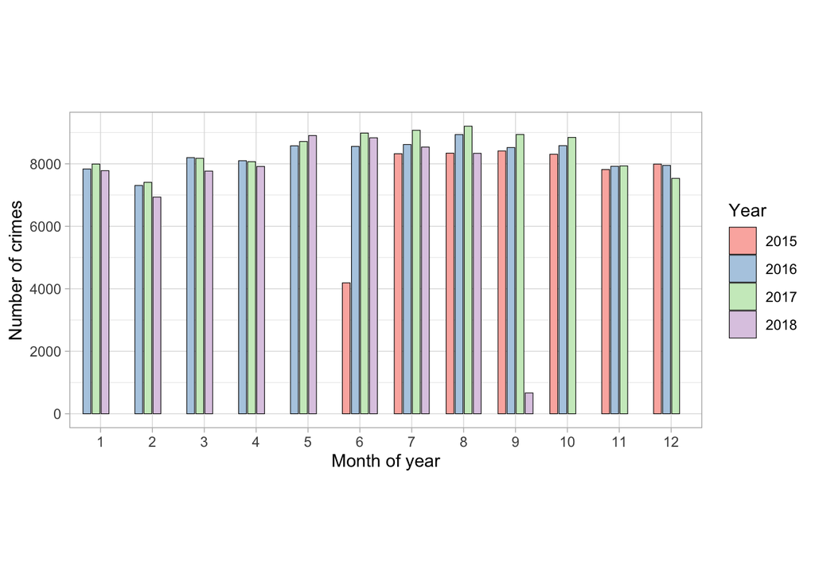

```r
ggplot(crimes,aes(x=factor(MONTH),fill=factor(YEAR))) +
  geom_bar(position=position_dodge(preserve='single',width=0.7),color='black',size=0.2,width=0.6) +
  scale_fill_brewer(palette='Pastel1') + theme_light() + theme(aspect.ratio=0.5) +
  labs(x="Month of year",y="Number of crimes",fill="Year") +
  scale_y_continuous(breaks=seq(0,10000,2000))
```

> The above plot does not show the actual picture because each year has different number of crimes so we need to scale it.

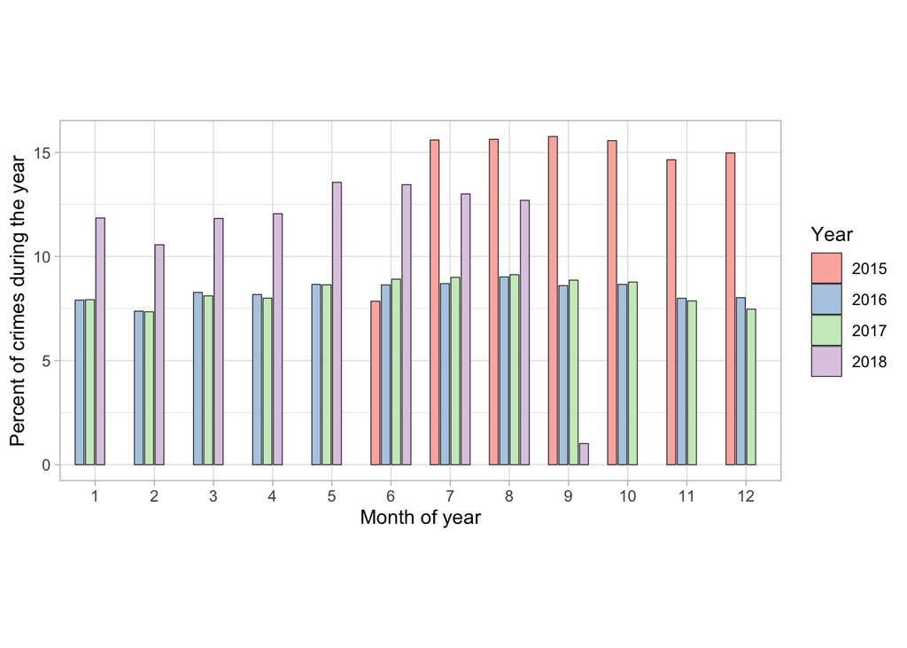

```r
c1 <- crimes %>% group_by(YEAR,MONTH) %>% summarise(total = n()) %>% mutate(Percent = total/sum(total)*100)
ggplot(c1,aes(x=factor(MONTH),y=Percent,fill=factor(YEAR))) +
  geom_bar(stat='identity',position=position_dodge(preserve='single',width=0.7),color='black',size=0.2,width=0.6) +
  scale_fill_brewer(palette = 'Pastel1') + theme_light() + theme(aspect.ratio=0.5) +
  labs(x="Month of year",y="Percent of crimes during the year",fill="Year")
```

> The above plto shows that the crimes happen all year round!

> In the same vein, does crime mostly occurs on weekdays or on weekeknds?

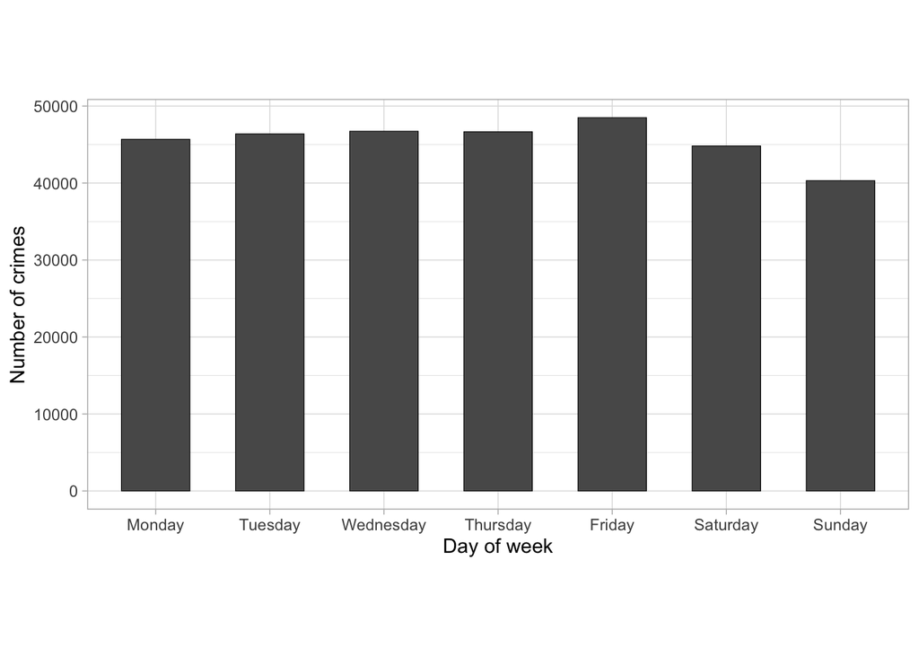

```r
crimes$DAY_OF_WEEK <- factor(crimes$DAY_OF_WEEK,levels=c("Monday","Tuesday","Wednesday","Thursday","Friday","Saturday","Sunday"))
ggplot(crimes,aes(x=factor(DAY_OF_WEEK,levels=c("Monday","Tuesday","Wednesday","Thursday","Friday","Saturday","Sunday")))) +
  geom_bar(position=position_dodge(preserve='single',width=0.7),color='black',size=0.2,width=0.6) +
  scale_fill_brewer(palette='Pastel1') + theme_light() + theme(aspect.ratio=0.5) +
  labs(x="Day of week",y="Number of crimes")
```

> There does appear to be a dip in crime over the weekend. Lets try to understand what drives it. Is it due to the nature of crime, such as burgluries that dont happen on weekend?

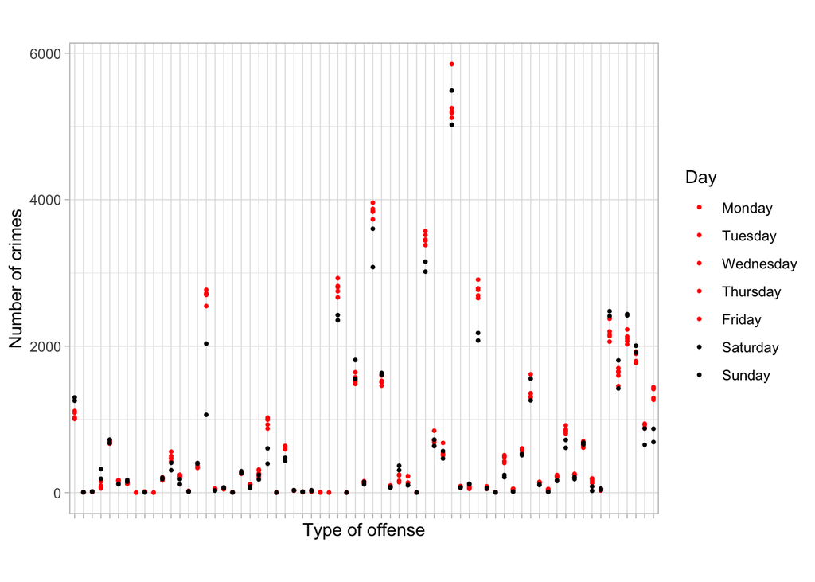

```r
c2 <- crimes %>% group_by(OFFENSE_CODE_GROUP,DAY_OF_WEEK) %>% summarise(total = n())
ggplot(c2,aes(x=factor(OFFENSE_CODE_GROUP),y=total,color=factor(DAY_OF_WEEK))) + geom_point(size=1,shape=16) +
  scale_colour_manual(values=c("red","red","red","red","red","black","black")) + theme_light() +
  theme(aspect.ratio=0.8,axis.text.x=element_blank()) +
  labs(x="Type of offense",y="Number of crimes",color="Day")
```

> The above plot shows that some kind of crimes increase on weekend and some decrese. Lets try to visualize this better:

```r
c31 <- c2 %>% filter(DAY_OF_WEEK == "Monday" | DAY_OF_WEEK == "Tuesday" | DAY_OF_WEEK == "Wednesday" | DAY_OF_WEEK == "Thursday" | DAY_OF_WEEK == "Friday") %>% summarise(weekday_avg = mean(total))
c32 <- c2 %>% filter(DAY_OF_WEEK == "Saturday" | DAY_OF_WEEK == "Sunday") %>% summarise(weekend_avg = mean(total))
c3 <- full_join(c31,c32)
```

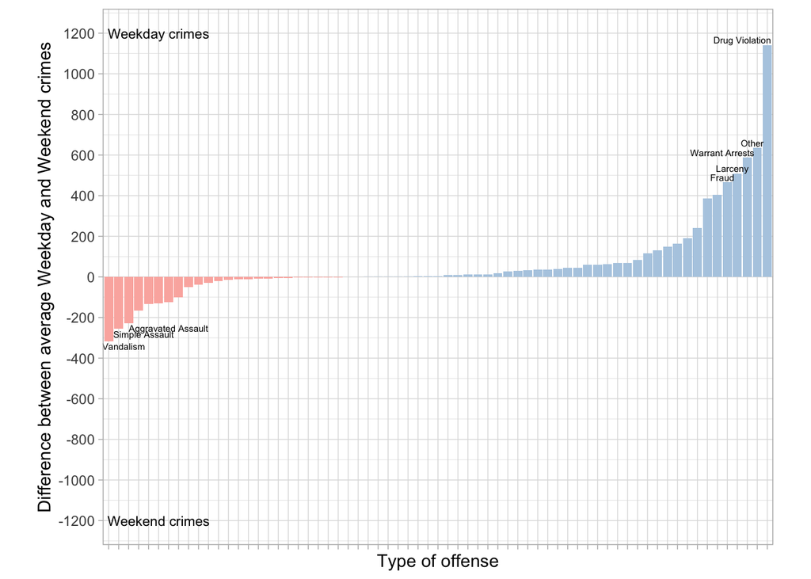

```r
c3 <- c3 %>% mutate(weekend_avg = replace_na(weekend_avg,0))
c3 <- c3 %>% mutate(weekday_avg = replace_na(weekday_avg,0))
c3 <- c3 %>% mutate(WkD_WkE_diff = weekday_avg - weekend_avg) %>% arrange(desc(WkD_WkE_diff))
c3$Pos = c3$WkD_WkE_diff >=0
ggplot(c3,aes(x=reorder(factor(OFFENSE_CODE_GROUP),WkD_WkE_diff),y=WkD_WkE_diff,fill=Pos)) + geom_bar(stat='identity') +
  scale_fill_brewer(palette = "Pastel1", guide=FALSE) + theme_light() + theme(aspect.ratio=0.8,axis.text.x=element_blank()) +
  labs(x="Type of offense",y="Difference between average Weekday and Weekend crimes") + coord_cartesian(ylim=c(-1200,1200)) +
  scale_y_continuous(breaks=seq(-1200,1200,200)) +
  annotate("text",size=2,x=c(67-2.5,66-0.5,65-2.5,64-0.5,63-0.5),y=unlist(c3[1:5,4]+25),label=c(as.character((unlist(c3[1:5,1]))))) +
  annotate("text",size=2,x=c(3+4,2+2.5,1+1.5),y=unlist(c3[65:67,4]-25),label=c(as.character((unlist(c3[65:67,1]))))) +
  annotate("text",size=3,x=c(6,6),y=c(-1200,1200),label=c("Weekend crimes","Weekday crimes"))
```

> This plot suggests that vandalism and assaults tend to happen more on weekends. The weekday higher crime number is driven by drug violations, arrest warrants, fraud etc. It makes me question if the crimes that are not considered “emergency” or necessary for maintaining peace and order get processed during weekdays when the police force is better staffed. But this is just a hypothesis and different data is needed to confirm or deny it.

> Do some kind of crimes like vandalism occur during a particular time of day. I wonder what insight we will get by looking at time of occurance of crime.

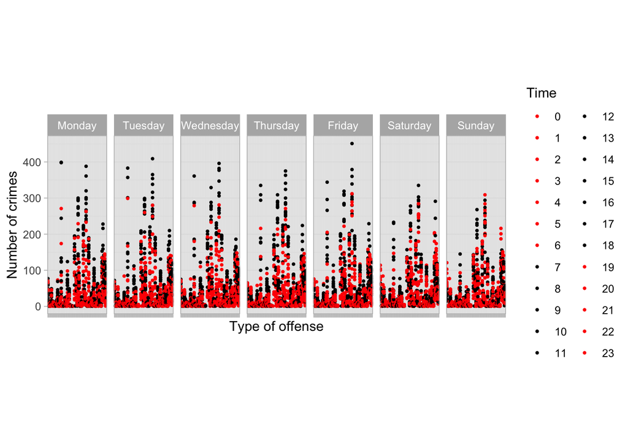

```r
c4 <- crimes %>% group_by(OFFENSE_CODE_GROUP,HOUR,DAY_OF_WEEK) %>% summarise(total = n())
ggplot(c4,aes(x=factor(OFFENSE_CODE_GROUP),y=total,color=factor(HOUR))) + geom_point(size=1,shape=16) +
  facet_grid(cols=vars(DAY_OF_WEEK)) +
  scale_colour_manual(values=c(rep("red",7),rep("black",12),rep("red",5))) + theme_light() +
  theme(aspect.ratio=3,axis.text.x=element_blank()) +
  labs(x="Type of offense",y="Number of crimes",color="Time")
```

> The above plot shows that some crimes happen during daytime and some nighfall. From this plot it does not seem that day of the week plays any role. So in the next iteration we will get rid of the facet: DAY_OF_WEEK and make a similar daytime vs nightime comparison as what we had done for day of the week.

```r
c4 <- crimes %>% group_by(OFFENSE_CODE_GROUP,HOUR) %>% summarise(total = n())
c51 <- c4 %>% filter(HOUR >= 7 & HOUR <= 18) %>% summarise(daytime = mean(total))
c52 <- c4 %>% filter(HOUR < 7 | HOUR >18) %>% summarise(nighttime = mean(total))
c5 <- full_join(c51,c52)
```

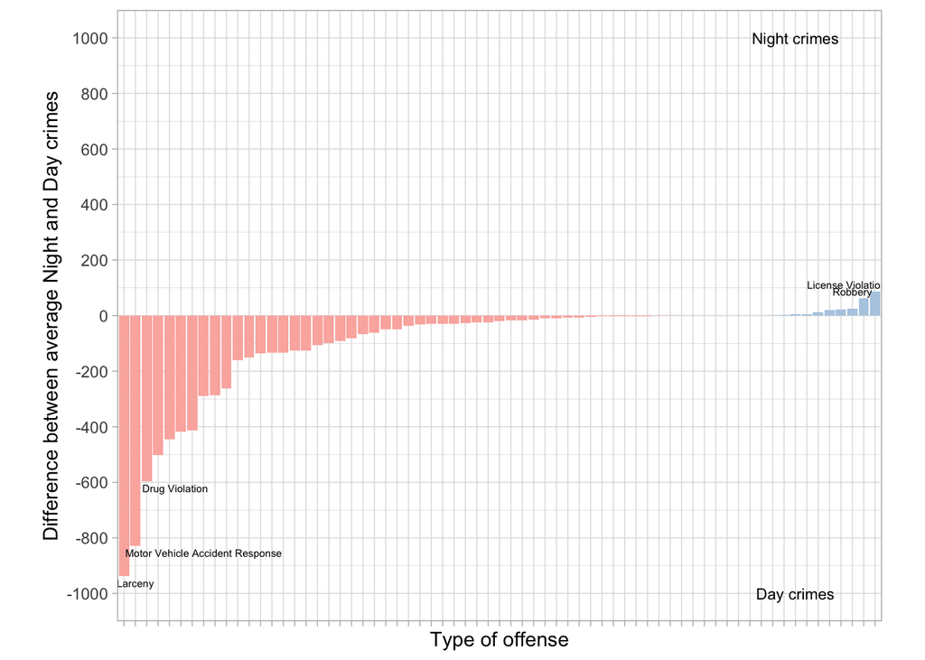

```r
c5 <- c5 %>% mutate(daytime = replace_na(daytime,0))
c5 <- c5 %>% mutate(nighttime = replace_na(nighttime,0))
c5 <- c5 %>% mutate(Night_Day_diff = nighttime - daytime) %>% arrange(desc(Night_Day_diff))
c5$Pos = c5$Night_Day_diff >=0
ggplot(c5,aes(x=reorder(factor(OFFENSE_CODE_GROUP),Night_Day_diff),y=Night_Day_diff,fill=Pos)) + geom_bar(stat='identity') +
  scale_fill_brewer(palette = "Pastel1", guide=FALSE) + theme_light() + theme(aspect.ratio=0.8,axis.text.x=element_blank()) +
  labs(x="Type of offense",y="Difference between average Night and Day crimes") + coord_cartesian(ylim=c(-1000,1000)) +
  scale_y_continuous(breaks=seq(-1000,1000,200)) +
  annotate("text",size=2,x=c(67-2.5,66-1),y=unlist(c5[1:2,4]+25),label=c(as.character((unlist(c5[1:2,1]))))) +
  annotate("text",size=2,x=c(3+2.5,2+6,1+1),y=unlist(c5[65:67,4]-25),label=c(as.character((unlist(c5[65:67,1]))))) +
  annotate("text",size=3,x=c(60,60),y=c(-1000,1000),label=c("Day crimes","Night crimes"))
```

> The above plot suggests that most crimes are happening during day. I do beleive that this is more a function of when the crime is getting reported rather than when it is happening.

> Lets also see what crimes are most likely to involve shooting.

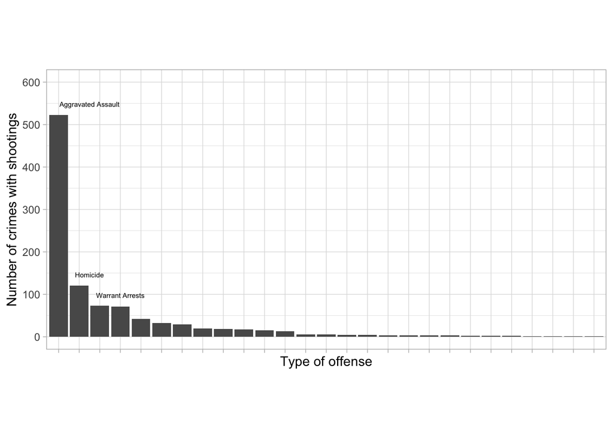

```r
c6 <- crimes %>% group_by(OFFENSE_CODE_GROUP) %>% filter(SHOOTING=="Y") %>% count(SHOOTING) %>% arrange(desc(n))
ggplot(c6,aes(x=reorder(factor(OFFENSE_CODE_GROUP),-n),y=n)) + geom_bar(stat='identity') +
  scale_fill_brewer(palette = "Pastel1", guide=FALSE) + theme_light() + theme(aspect.ratio=0.5,axis.text.x=element_blank()) +
  labs(x="Type of offense",y="Number of crimes with shootings") + coord_cartesian(ylim=c(0,600)) +
  scale_y_continuous(breaks=seq(0,600,100)) +
  annotate("text",size=2,x=c(1+1.5,2+0.5,3+1),y=unlist(c6[1:3,3]+25),label=c(as.character((unlist(c6[1:3,1])))))
```

> As expected its violent crimes. Surprisingly its also warrant based arrests. Wondering if police can somehow de-escalate arrests to reduce shootings.

> Lets now now dig into geographical data on where crime is occuring in Boston. And how it has changed over the last 3 years.

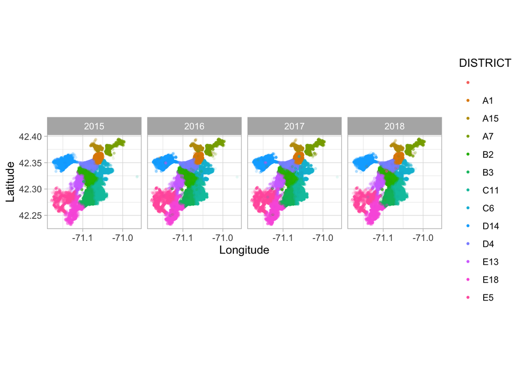

```r
c7 <- crimes %>% filter(Long!=-1)
ggplot(c7,aes(y=Lat,x=Long,color=DISTRICT)) + geom_point(size=1,shape=16,alpha=0.1) + facet_grid(cols=vars(YEAR)) +
  labs(x="Longitude",y="Latitude") + guides(colour=guide_legend(override.aes=list(alpha=1))) + theme_light() + theme(aspect.ratio=1) +
  scale_x_continuous(breaks=seq(-71.2,-70.9,0.1)) + scale_y_continuous(breaks=seq(42.1,42.4,0.05))
```

> The above plot shows that more or less crime distribution was similar for each year. So we can ignore that as a factor when breaking down the type of crimes. Lets look at where top 12 crimes occur in Boston.

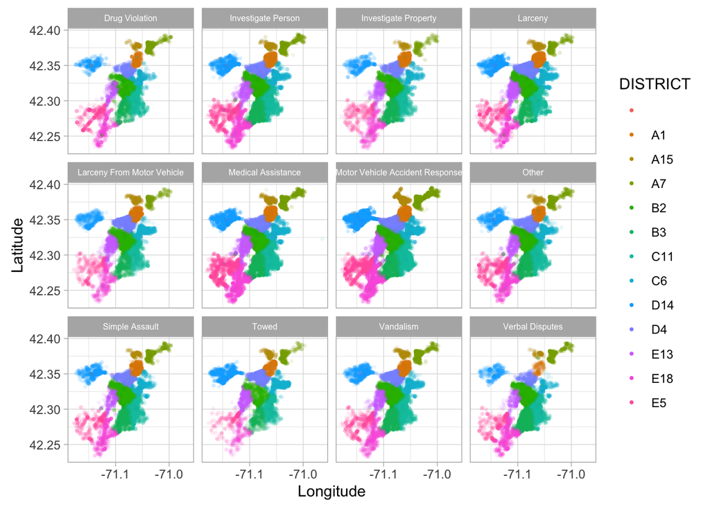

```r
c8 <- c7 %>% group_by(OFFENSE_CODE_GROUP) %>% summarise(total = n()) %>% arrange(desc(total))
c9 <- c7 %>% filter(OFFENSE_CODE_GROUP %in% unlist(c8[1:12,1]))
ggplot(c9,aes(y=Lat,x=Long,color=DISTRICT)) + geom_point(size=1,shape=16,alpha=0.1) + facet_wrap(vars(OFFENSE_CODE_GROUP)) +
  labs(x="Longitude",y="Latitude") + theme_light() + theme(aspect.ratio=1,strip.text = element_text(size = 6)) +
  scale_x_continuous(breaks=seq(-71.2,-70.9,0.1)) + scale_y_continuous(breaks=seq(42.1,42.4,0.05)) +
  guides(colour=guide_legend(override.aes=list(alpha=1)))
```

> The above plot is hard to see even though we have a very high transparency due to crime density. So we will bin the events to create a better visualization.

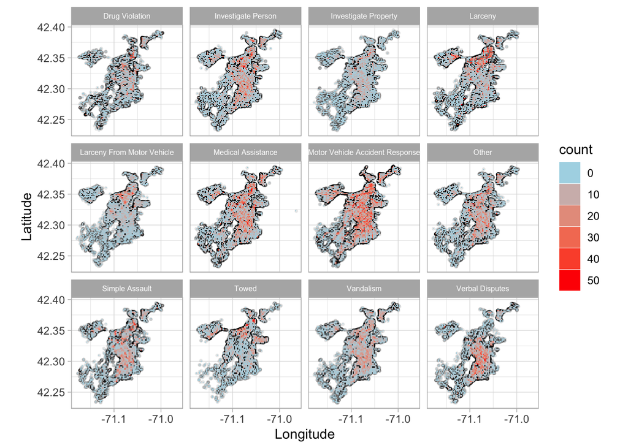

```r
ggplot(c9,aes(y=Lat,x=Long)) + geom_point(size=1,shape=16,alpha=0.1) + facet_wrap(vars(OFFENSE_CODE_GROUP)) +
  labs(x="Longitude",y="Latitude") + theme_light() + theme(aspect.ratio=1,strip.text = element_text(size = 6)) +
  scale_x_continuous(breaks=seq(-71.2,-70.9,0.1)) + scale_y_continuous(breaks=seq(42.1,42.4,0.05)) +
  stat_bin_2d(bins=100) + scale_fill_gradient(low="lightblue",high="red",limits=c(0,50),guide="legend")
```

> In summary, the above charts help us better visualize the crime data in Boston during the 4 year period.